# Risk Factor Analysis

## Outcome Variable

**Outcome Variable:** stunted

## Predictor Variables

**Intervention Variable:** feducyrs

**Adjustment Set:**

unadjusted

## Stratifying Variables

The analysis was stratified on these variable(s):

- agecat
- studyid
- country

## Data Summary

| agecat | studyid | country | feducyrs | stunted | n_cell | n |
| --- | --- | --- | --- | --- | --- | --- |
| Birth | ki0047075b-MAL-ED | BANGLADESH | Low | 0 | 30 | 144 |
| Birth | ki0047075b-MAL-ED | BANGLADESH | Low | 1 | 8 | 144 |
| Birth | ki0047075b-MAL-ED | BANGLADESH | Medium | 0 | 44 | 144 |
| Birth | ki0047075b-MAL-ED | BANGLADESH | Medium | 1 | 10 | 144 |
| Birth | ki0047075b-MAL-ED | BANGLADESH | High | 0 | 44 | 144 |
| Birth | ki0047075b-MAL-ED | BANGLADESH | High | 1 | 8 | 144 |
| Birth | ki0047075b-MAL-ED | INDIA | Low | 0 | 46 | 123 |
| Birth | ki0047075b-MAL-ED | INDIA | Low | 1 | 4 | 123 |
| Birth | ki0047075b-MAL-ED | INDIA | Medium | 0 | 30 | 123 |
| Birth | ki0047075b-MAL-ED | INDIA | Medium | 1 | 5 | 123 |
| Birth | ki0047075b-MAL-ED | INDIA | High | 0 | 32 | 123 |
| Birth | ki0047075b-MAL-ED | INDIA | High | 1 | 6 | 123 |
| Birth | ki0047075b-MAL-ED | NEPAL | Low | 0 | 17 | 67 |
| Birth | ki0047075b-MAL-ED | NEPAL | Low | 1 | 2 | 67 |
| Birth | ki0047075b-MAL-ED | NEPAL | Medium | 0 | 16 | 67 |
| Birth | ki0047075b-MAL-ED | NEPAL | Medium | 1 | 5 | 67 |
| Birth | ki0047075b-MAL-ED | NEPAL | High | 0 | 26 | 67 |
| Birth | ki0047075b-MAL-ED | NEPAL | High | 1 | 1 | 67 |
| Birth | ki0047075b-MAL-ED | PERU | Low | 0 | 52 | 236 |
| Birth | ki0047075b-MAL-ED | PERU | Low | 1 | 13 | 236 |
| Birth | ki0047075b-MAL-ED | PERU | Medium | 0 | 52 | 236 |
| Birth | ki0047075b-MAL-ED | PERU | Medium | 1 | 3 | 236 |
| Birth | ki0047075b-MAL-ED | PERU | High | 0 | 106 | 236 |
| Birth | ki0047075b-MAL-ED | PERU | High | 1 | 10 | 236 |
| Birth | ki0047075b-MAL-ED | SOUTH AFRICA | Low | 0 | 30 | 91 |
| Birth | ki0047075b-MAL-ED | SOUTH AFRICA | Low | 1 | 0 | 91 |
| Birth | ki0047075b-MAL-ED | SOUTH AFRICA | Medium | 0 | 23 | 91 |
| Birth | ki0047075b-MAL-ED | SOUTH AFRICA | Medium | 1 | 3 | 91 |
| Birth | ki0047075b-MAL-ED | SOUTH AFRICA | High | 0 | 30 | 91 |
| Birth | ki0047075b-MAL-ED | SOUTH AFRICA | High | 1 | 5 | 91 |

[output cut: 288 more lines]

The following strata were considered:

- agecat: 24 months, studyid: ki0047075b-MAL-ED, country: BANGLADESH
- agecat: 24 months, studyid: ki0047075b-MAL-ED, country: INDIA
- agecat: 24 months, studyid: ki0047075b-MAL-ED, country: NEPAL
- agecat: 24 months, studyid: ki0047075b-MAL-ED, country: PERU
- agecat: 24 months, studyid: ki0047075b-MAL-ED, country: SOUTH AFRICA
- agecat: 24 months, studyid: ki0047075b-MAL-ED, country: TANZANIA, UNITED REPUBLIC OF
- agecat: 24 months, studyid: ki1017093b-PROVIDE, country: BANGLADESH
- agecat: 24 months, studyid: ki1017093c-NIH-Crypto, country: BANGLADESH
- agecat: 24 months, studyid: ki1066203-TanzaniaChild2, country: TANZANIA, UNITED REPUBLIC OF
- agecat: 24 months, studyid: ki1113344-GMS-Nepal, country: NEPAL
- agecat: 24 months, studyid: ki1119695-PROBIT, country: BELARUS
- agecat: 24 months, studyid: ki1126311-ZVITAMBO, country: ZIMBABWE
- agecat: 24 months, studyid: ki1135781-COHORTS, country: GUATEMALA
- agecat: 24 months, studyid: ki1135781-COHORTS, country: INDIA
- agecat: 24 months, studyid: ki1135781-COHORTS, country: PHILIPPINES
- agecat: 24 months, studyid: ki1148112-LCNI-5, country: MALAWI
- agecat: 24 months, studyid: kiGH5241-JiVitA-3, country: BANGLADESH
- agecat: 24 months, studyid: kiGH5241-JiVitA-4, country: BANGLADESH
- agecat: 6 months, studyid: ki0047075b-MAL-ED, country: BANGLADESH
- agecat: 6 months, studyid: ki0047075b-MAL-ED, country: INDIA
- agecat: 6 months, studyid: ki0047075b-MAL-ED, country: NEPAL
- agecat: 6 months, studyid: ki0047075b-MAL-ED, country: PERU
- agecat: 6 months, studyid: ki0047075b-MAL-ED, country: SOUTH AFRICA
- agecat: 6 months, studyid: ki0047075b-MAL-ED, country: TANZANIA, UNITED REPUBLIC OF
- agecat: 6 months, studyid: ki1000304b-SAS-CompFeed, country: INDIA
- agecat: 6 months, studyid: ki1000304b-SAS-FoodSuppl, country: INDIA
- agecat: 6 months, studyid: ki1017093b-PROVIDE, country: BANGLADESH
- agecat: 6 months, studyid: ki1017093c-NIH-Crypto, country: BANGLADESH
- agecat: 6 months, studyid: ki1066203-TanzaniaChild2, country: TANZANIA, UNITED REPUBLIC OF
- agecat: 6 months, studyid: ki1113344-GMS-Nepal, country: NEPAL
- agecat: 6 months, studyid: ki1119695-PROBIT, country: BELARUS
- agecat: 6 months, studyid: ki1126311-ZVITAMBO, country: ZIMBABWE
- agecat: 6 months, studyid: ki1135781-COHORTS, country: GUATEMALA
- agecat: 6 months, studyid: ki1135781-COHORTS, country: INDIA
- agecat: 6 months, studyid: ki1135781-COHORTS, country: PHILIPPINES
- agecat: 6 months, studyid: ki1148112-LCNI-5, country: MALAWI
- agecat: 6 months, studyid: kiGH5241-JiVitA-3, country: BANGLADESH
- agecat: 6 months, studyid: kiGH5241-JiVitA-4, country: BANGLADESH
- agecat: Birth, studyid: ki0047075b-MAL-ED, country: BANGLADESH
- agecat: Birth, studyid: ki0047075b-MAL-ED, country: INDIA
- agecat: Birth, studyid: ki0047075b-MAL-ED, country: NEPAL
- agecat: Birth, studyid: ki0047075b-MAL-ED, country: PERU
- agecat: Birth, studyid: ki0047075b-MAL-ED, country: SOUTH AFRICA
- agecat: Birth, studyid: ki0047075b-MAL-ED, country: TANZANIA, UNITED REPUBLIC OF
- agecat: Birth, studyid: ki1000304b-SAS-CompFeed, country: INDIA
- agecat: Birth, studyid: ki1017093c-NIH-Crypto, country: BANGLADESH
- agecat: Birth, studyid: ki1119695-PROBIT, country: BELARUS
- agecat: Birth, studyid: ki1126311-ZVITAMBO, country: ZIMBABWE
- agecat: Birth, studyid: ki1135781-COHORTS, country: GUATEMALA
- agecat: Birth, studyid: ki1135781-COHORTS, country: INDIA
- agecat: Birth, studyid: ki1135781-COHORTS, country: PHILIPPINES
- agecat: Birth, studyid: kiGH5241-JiVitA-3, country: BANGLADESH
- agecat: Birth, studyid: kiGH5241-JiVitA-4, country: BANGLADESH

### Dropped Strata

Some strata were dropped due to rare outcomes:

- agecat: Birth, studyid: ki0047075b-MAL-ED, country: INDIA
- agecat: Birth, studyid: ki0047075b-MAL-ED, country: NEPAL
- agecat: Birth, studyid: ki0047075b-MAL-ED, country: PERU
- agecat: Birth, studyid: ki0047075b-MAL-ED, country: SOUTH AFRICA
- agecat: Birth, studyid: ki0047075b-MAL-ED, country: TANZANIA, UNITED REPUBLIC OF
- agecat: Birth, studyid: ki1000304b-SAS-CompFeed, country: INDIA
- agecat: Birth, studyid: ki1017093c-NIH-Crypto, country: BANGLADESH
- agecat: Birth, studyid: ki1119695-PROBIT, country: BELARUS
- agecat: 6 months, studyid: ki0047075b-MAL-ED, country: NEPAL
- agecat: 6 months, studyid: ki0047075b-MAL-ED, country: SOUTH AFRICA
- agecat: 24 months, studyid: ki0047075b-MAL-ED, country: TANZANIA, UNITED REPUBLIC OF
- agecat: 24 months, studyid: ki1066203-TanzaniaChild2, country: TANZANIA, UNITED REPUBLIC OF

## Methods Detail

We’re interested in the causal parameters $E[Y_a]$ for all values of $a \in \mathcal{A}$. These parameters represent the mean outcome if, possibly contrary to fact, we intervened to set all units to have $A=a$. Under the randomization and positivity assumptions, these are identified by the statistical parameters $\psi_a=E_W[E_{Y|A,W}(Y|A=a,W)]$. In addition, we’re interested in the mean of $Y$, $E[Y]$ under no intervention (the observed mean). We will estimate these parameters by using SuperLearner to fit the relevant likelihood factors – $E_{Y|A,W}(Y|A=a,W)$ and $p(A=a|W)$, and then updating our likelihood fit using a joint TMLE.

For unadjusted analyses ($W=\{\}$), initial likelihoods were estimated using Lrnr_glm to estimate the simple $E(Y|A)$ and Lrnr_mean to estimate $p(A)$. For adjusted analyses, a small library containing Lrnr_glmnet, Lrnr_xgboost, and Lrnr_mean was used.

Having estimated these parameters, we will then use the delta method to estimate relative risks and attributable risks relative to a prespecified baseline level of $A$.

# Results Detail

## Results Plots

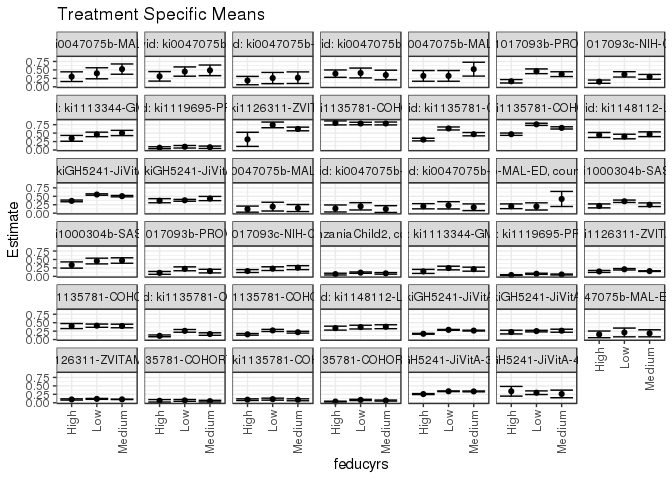

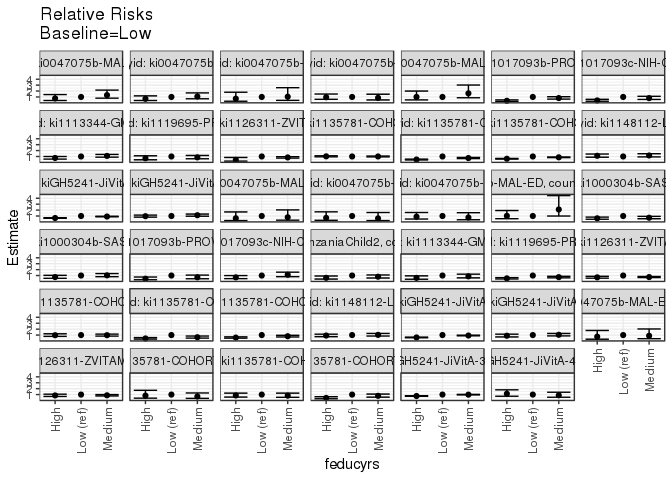

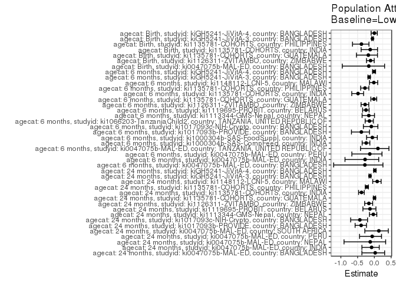

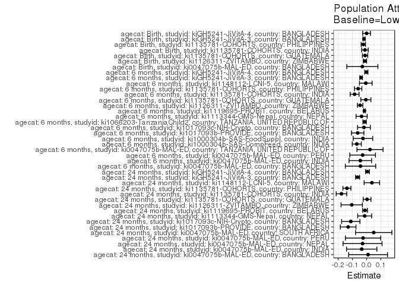

## Results Table

### Parameter: TSM

| agecat | studyid | country | intervention_level | baseline_level | estimate | ci_lower | ci_upper |
| --- | --- | --- | --- | --- | --- | --- | --- |
| Birth | ki0047075b-MAL-ED | BANGLADESH | Low | NA | 0.2105263 | 0.0804520 | 0.3406006 |
| Birth | ki0047075b-MAL-ED | BANGLADESH | Medium | NA | 0.1851852 | 0.0812178 | 0.2891525 |
| Birth | ki0047075b-MAL-ED | BANGLADESH | High | NA | 0.1538462 | 0.0554388 | 0.2522535 |
| Birth | ki1126311-ZVITAMBO | ZIMBABWE | Low | NA | 0.1146749 | 0.1015841 | 0.1277656 |
| Birth | ki1126311-ZVITAMBO | ZIMBABWE | Medium | NA | 0.1008033 | 0.0949627 | 0.1066439 |
| Birth | ki1126311-ZVITAMBO | ZIMBABWE | High | NA | 0.0983607 | 0.0796768 | 0.1170445 |
| Birth | ki1135781-COHORTS | GUATEMALA | Low | NA | 0.0704225 | 0.0437906 | 0.0970545 |
| Birth | ki1135781-COHORTS | GUATEMALA | Medium | NA | 0.0476190 | 0.0232611 | 0.0719770 |
| Birth | ki1135781-COHORTS | GUATEMALA | High | NA | 0.0580645 | 0.0212246 | 0.0949044 |
| Birth | ki1135781-COHORTS | INDIA | Low | NA | 0.1070615 | 0.0781278 | 0.1359952 |
| Birth | ki1135781-COHORTS | INDIA | Medium | NA | 0.0876289 | 0.0594838 | 0.1157739 |
| Birth | ki1135781-COHORTS | INDIA | High | NA | 0.0910816 | 0.0665073 | 0.1156559 |
| Birth | ki1135781-COHORTS | PHILIPPINES | Low | NA | 0.0834341 | 0.0645835 | 0.1022847 |
| Birth | ki1135781-COHORTS | PHILIPPINES | Medium | NA | 0.0657507 | 0.0505306 | 0.0809709 |
| Birth | ki1135781-COHORTS | PHILIPPINES | High | NA | 0.0360273 | 0.0246277 | 0.0474268 |
| Birth | kiGH5241-JiVitA-3 | BANGLADESH | Low | NA | 0.3401039 | 0.3293332 | 0.3508747 |
| Birth | kiGH5241-JiVitA-3 | BANGLADESH | Medium | NA | 0.3361319 | 0.3235616 | 0.3487022 |
| Birth | kiGH5241-JiVitA-3 | BANGLADESH | High | NA | 0.2572841 | 0.2423793 | 0.2721889 |
| Birth | kiGH5241-JiVitA-4 | BANGLADESH | Low | NA | 0.2972973 | 0.2435140 | 0.3510806 |
| Birth | kiGH5241-JiVitA-4 | BANGLADESH | Medium | NA | 0.2615385 | 0.1492990 | 0.3737780 |
| Birth | kiGH5241-JiVitA-4 | BANGLADESH | High | NA | 0.3396226 | 0.1961323 | 0.4831129 |
| 6 months | ki0047075b-MAL-ED | BANGLADESH | Low | NA | 0.1944444 | 0.0646687 | 0.3242202 |
| 6 months | ki0047075b-MAL-ED | BANGLADESH | Medium | NA | 0.1521739 | 0.0479796 | 0.2563682 |
| 6 months | ki0047075b-MAL-ED | BANGLADESH | High | NA | 0.1200000 | 0.0295838 | 0.2104162 |
| 6 months | ki0047075b-MAL-ED | INDIA | Low | NA | 0.2037037 | 0.0958917 | 0.3115157 |
| 6 months | ki0047075b-MAL-ED | INDIA | Medium | NA | 0.1219512 | 0.0214230 | 0.2224794 |
| 6 months | ki0047075b-MAL-ED | INDIA | High | NA | 0.1395349 | 0.0355905 | 0.2434793 |
| 6 months | ki0047075b-MAL-ED | PERU | Low | NA | 0.2333333 | 0.1260738 | 0.3405928 |
| 6 months | ki0047075b-MAL-ED | PERU | Medium | NA | 0.1754386 | 0.0764794 | 0.2743978 |
| 6 months | ki0047075b-MAL-ED | PERU | High | NA | 0.2056075 | 0.1288599 | 0.2823551 |

[output cut: 93 more lines]

### Parameter: E(Y)

| agecat | studyid | country | intervention_level | baseline_level | estimate | ci_lower | ci_upper |
| --- | --- | --- | --- | --- | --- | --- | --- |
| Birth | ki0047075b-MAL-ED | BANGLADESH | NA | NA | 0.1805556 | 0.1175113 | 0.2435998 |
| Birth | ki1126311-ZVITAMBO | ZIMBABWE | NA | NA | 0.1029718 | 0.0978372 | 0.1081063 |
| Birth | ki1135781-COHORTS | GUATEMALA | NA | NA | 0.0597015 | 0.0433139 | 0.0760891 |
| Birth | ki1135781-COHORTS | INDIA | NA | NA | 0.0952733 | 0.0796294 | 0.1109171 |
| Birth | ki1135781-COHORTS | PHILIPPINES | NA | NA | 0.0602158 | 0.0515157 | 0.0689159 |
| Birth | kiGH5241-JiVitA-3 | BANGLADESH | NA | NA | 0.3218470 | 0.3140700 | 0.3296240 |
| Birth | kiGH5241-JiVitA-4 | BANGLADESH | NA | NA | 0.2971175 | 0.2506806 | 0.3435544 |
| 6 months | ki0047075b-MAL-ED | BANGLADESH | NA | NA | 0.1515152 | 0.0901160 | 0.2129143 |
| 6 months | ki0047075b-MAL-ED | INDIA | NA | NA | 0.1594203 | 0.0981219 | 0.2207187 |
| 6 months | ki0047075b-MAL-ED | PERU | NA | NA | 0.2053571 | 0.1523375 | 0.2583768 |
| 6 months | ki0047075b-MAL-ED | TANZANIA, UNITED REPUBLIC OF | NA | NA | 0.2238806 | 0.1661102 | 0.2816510 |
| 6 months | ki1000304b-SAS-CompFeed | INDIA | NA | NA | 0.2835709 | 0.2656121 | 0.3015297 |
| 6 months | ki1000304b-SAS-FoodSuppl | INDIA | NA | NA | 0.4289474 | 0.3791199 | 0.4787748 |
| 6 months | ki1017093b-PROVIDE | BANGLADESH | NA | NA | 0.1612350 | 0.1313580 | 0.1911120 |
| 6 months | ki1017093c-NIH-Crypto | BANGLADESH | NA | NA | 0.2097902 | 0.1799252 | 0.2396552 |
| 6 months | ki1066203-TanzaniaChild2 | TANZANIA, UNITED REPUBLIC OF | NA | NA | 0.0966303 | 0.0837364 | 0.1095242 |
| 6 months | ki1113344-GMS-Nepal | NEPAL | NA | NA | 0.2117438 | 0.1779368 | 0.2455507 |
| 6 months | ki1119695-PROBIT | BELARUS | NA | NA | 0.0613372 | 0.0479409 | 0.0747335 |
| 6 months | ki1126311-ZVITAMBO | ZIMBABWE | NA | NA | 0.1645789 | 0.1564849 | 0.1726730 |
| 6 months | ki1135781-COHORTS | GUATEMALA | NA | NA | 0.4059735 | 0.3739435 | 0.4380034 |
| 6 months | ki1135781-COHORTS | INDIA | NA | NA | 0.1732852 | 0.1533446 | 0.1932258 |
| 6 months | ki1135781-COHORTS | PHILIPPINES | NA | NA | 0.2113885 | 0.1955816 | 0.2271953 |
| 6 months | ki1148112-LCNI-5 | MALAWI | NA | NA | 0.3633005 | 0.3301997 | 0.3964012 |
| 6 months | kiGH5241-JiVitA-3 | BANGLADESH | NA | NA | 0.2492707 | 0.2410138 | 0.2575276 |
| 6 months | kiGH5241-JiVitA-4 | BANGLADESH | NA | NA | 0.2491156 | 0.2297596 | 0.2684716 |
| 24 months | ki0047075b-MAL-ED | BANGLADESH | NA | NA | 0.4102564 | 0.3207450 | 0.4997678 |
| 24 months | ki0047075b-MAL-ED | INDIA | NA | NA | 0.4166667 | 0.3322428 | 0.5010905 |
| 24 months | ki0047075b-MAL-ED | NEPAL | NA | NA | 0.2307692 | 0.1437242 | 0.3178143 |
| 24 months | ki0047075b-MAL-ED | PERU | NA | NA | 0.3841463 | 0.3094772 | 0.4588155 |
| 24 months | ki0047075b-MAL-ED | SOUTH AFRICA | NA | NA | 0.3736264 | 0.2736811 | 0.4735717 |
| 24 months | ki1017093b-PROVIDE | BANGLADESH | NA | NA | 0.3292894 | 0.2909105 | 0.3676684 |
| 24 months | ki1017093c-NIH-Crypto | BANGLADESH | NA | NA | 0.2568093 | 0.2190047 | 0.2946140 |
| 24 months | ki1113344-GMS-Nepal | NEPAL | NA | NA | 0.4477912 | 0.4040733 | 0.4915091 |
| 24 months | ki1119695-PROBIT | BELARUS | NA | NA | 0.0845898 | 0.0544909 | 0.1146887 |
| 24 months | ki1126311-ZVITAMBO | ZIMBABWE | NA | NA | 0.6382488 | 0.5929899 | 0.6835078 |
| 24 months | ki1135781-COHORTS | GUATEMALA | NA | NA | 0.7879397 | 0.7625282 | 0.8133512 |
| 24 months | ki1135781-COHORTS | INDIA | NA | NA | 0.4608696 | 0.4345607 | 0.4871784 |
| 24 months | ki1135781-COHORTS | PHILIPPINES | NA | NA | 0.6214347 | 0.6016683 | 0.6412012 |
| 24 months | ki1148112-LCNI-5 | MALAWI | NA | NA | 0.4360771 | 0.3953670 | 0.4767872 |
| 24 months | kiGH5241-JiVitA-3 | BANGLADESH | NA | NA | 0.4886096 | 0.4753690 | 0.5018502 |
| 24 months | kiGH5241-JiVitA-4 | BANGLADESH | NA | NA | 0.3880966 | 0.3646676 | 0.4115256 |

### Parameter: RR

| agecat | studyid | country | intervention_level | baseline_level | estimate | ci_lower | ci_upper |
| --- | --- | --- | --- | --- | --- | --- | --- |
| Birth | ki0047075b-MAL-ED | BANGLADESH | Low | Low | 1.0000000 | 1.0000000 | 1.0000000 |
| Birth | ki0047075b-MAL-ED | BANGLADESH | Medium | Low | 0.8796296 | 0.3817142 | 2.0270354 |
| Birth | ki0047075b-MAL-ED | BANGLADESH | High | Low | 0.7307692 | 0.3002984 | 1.7783099 |
| Birth | ki1126311-ZVITAMBO | ZIMBABWE | Low | Low | 1.0000000 | 1.0000000 | 1.0000000 |
| Birth | ki1126311-ZVITAMBO | ZIMBABWE | Medium | Low | 0.8790356 | 0.7734088 | 0.9990882 |
| Birth | ki1126311-ZVITAMBO | ZIMBABWE | High | Low | 0.8577351 | 0.6872375 | 1.0705316 |
| Birth | ki1135781-COHORTS | GUATEMALA | Low | Low | 1.0000000 | 1.0000000 | 1.0000000 |
| Birth | ki1135781-COHORTS | GUATEMALA | Medium | Low | 0.6761905 | 0.3579318 | 1.2774321 |
| Birth | ki1135781-COHORTS | GUATEMALA | High | Low | 0.8245161 | 0.3939310 | 1.7257513 |
| Birth | ki1135781-COHORTS | INDIA | Low | Low | 1.0000000 | 1.0000000 | 1.0000000 |
| Birth | ki1135781-COHORTS | INDIA | Medium | Low | 0.8184909 | 0.5379173 | 1.2454094 |
| Birth | ki1135781-COHORTS | INDIA | High | Low | 0.8507408 | 0.5806967 | 1.2463648 |
| Birth | ki1135781-COHORTS | PHILIPPINES | Low | Low | 1.0000000 | 1.0000000 | 1.0000000 |
| Birth | ki1135781-COHORTS | PHILIPPINES | Medium | Low | 0.7880559 | 0.5702663 | 1.0890214 |
| Birth | ki1135781-COHORTS | PHILIPPINES | High | Low | 0.4318050 | 0.2927083 | 0.6370014 |
| Birth | kiGH5241-JiVitA-3 | BANGLADESH | Low | Low | 1.0000000 | 1.0000000 | 1.0000000 |
| Birth | kiGH5241-JiVitA-3 | BANGLADESH | Medium | Low | 0.9883211 | 0.9443516 | 1.0343378 |
| Birth | kiGH5241-JiVitA-3 | BANGLADESH | High | Low | 0.7564867 | 0.7082512 | 0.8080073 |
| Birth | kiGH5241-JiVitA-4 | BANGLADESH | Low | Low | 1.0000000 | 1.0000000 | 1.0000000 |
| Birth | kiGH5241-JiVitA-4 | BANGLADESH | Medium | Low | 0.8797203 | 0.5527134 | 1.4001973 |
| Birth | kiGH5241-JiVitA-4 | BANGLADESH | High | Low | 1.1423671 | 0.7231340 | 1.8046483 |
| 6 months | ki0047075b-MAL-ED | BANGLADESH | Low | Low | 1.0000000 | 1.0000000 | 1.0000000 |
| 6 months | ki0047075b-MAL-ED | BANGLADESH | Medium | Low | 0.7826087 | 0.3008040 | 2.0361313 |
| 6 months | ki0047075b-MAL-ED | BANGLADESH | High | Low | 0.6171429 | 0.2255498 | 1.6886084 |
| 6 months | ki0047075b-MAL-ED | INDIA | Low | Low | 1.0000000 | 1.0000000 | 1.0000000 |
| 6 months | ki0047075b-MAL-ED | INDIA | Medium | Low | 0.5986696 | 0.2247749 | 1.5945080 |
| 6 months | ki0047075b-MAL-ED | INDIA | High | Low | 0.6849894 | 0.2746771 | 1.7082256 |
| 6 months | ki0047075b-MAL-ED | PERU | Low | Low | 1.0000000 | 1.0000000 | 1.0000000 |
| 6 months | ki0047075b-MAL-ED | PERU | Medium | Low | 0.7518797 | 0.3631884 | 1.5565560 |
| 6 months | ki0047075b-MAL-ED | PERU | High | Low | 0.8811749 | 0.4874104 | 1.5930502 |

[output cut: 93 more lines]

### Parameter: PAR

| agecat | studyid | country | intervention_level | baseline_level | estimate | ci_lower | ci_upper |
| --- | --- | --- | --- | --- | --- | --- | --- |
| Birth | ki0047075b-MAL-ED | BANGLADESH | Low | NA | -0.0299708 | -0.1393520 | 0.0794105 |
| Birth | ki1126311-ZVITAMBO | ZIMBABWE | Low | NA | -0.0117031 | -0.0235258 | 0.0001196 |
| Birth | ki1135781-COHORTS | GUATEMALA | Low | NA | -0.0107210 | -0.0294688 | 0.0080267 |
| Birth | ki1135781-COHORTS | INDIA | Low | NA | -0.0117882 | -0.0350053 | 0.0114289 |
| Birth | ki1135781-COHORTS | PHILIPPINES | Low | NA | -0.0232183 | -0.0382670 | -0.0081696 |
| Birth | kiGH5241-JiVitA-3 | BANGLADESH | Low | NA | -0.0182569 | -0.0259101 | -0.0106038 |
| Birth | kiGH5241-JiVitA-4 | BANGLADESH | Low | NA | -0.0001798 | -0.0274730 | 0.0271135 |
| 6 months | ki0047075b-MAL-ED | BANGLADESH | Low | NA | -0.0429293 | -0.1498180 | 0.0639594 |
| 6 months | ki0047075b-MAL-ED | INDIA | Low | NA | -0.0442834 | -0.1235572 | 0.0349903 |
| 6 months | ki0047075b-MAL-ED | PERU | Low | NA | -0.0279762 | -0.1182674 | 0.0623150 |
| 6 months | ki0047075b-MAL-ED | TANZANIA, UNITED REPUBLIC OF | Low | NA | 0.0238806 | -0.0678915 | 0.1156527 |
| 6 months | ki1000304b-SAS-CompFeed | INDIA | Low | NA | -0.0691564 | -0.1010932 | -0.0372195 |
| 6 months | ki1000304b-SAS-FoodSuppl | INDIA | Low | NA | -0.0255981 | -0.0940902 | 0.0428940 |
| 6 months | ki1017093b-PROVIDE | BANGLADESH | Low | NA | -0.0626456 | -0.1065249 | -0.0187663 |
| 6 months | ki1017093c-NIH-Crypto | BANGLADESH | Low | NA | -0.0189093 | -0.0640395 | 0.0262208 |
| 6 months | ki1066203-TanzaniaChild2 | TANZANIA, UNITED REPUBLIC OF | Low | NA | -0.0141730 | -0.0260309 | -0.0023151 |
| 6 months | ki1113344-GMS-Nepal | NEPAL | Low | NA | -0.0351698 | -0.0744271 | 0.0040875 |
| 6 months | ki1119695-PROBIT | BELARUS | Low | NA | -0.0153149 | -0.0215575 | -0.0090723 |
| 6 months | ki1126311-ZVITAMBO | ZIMBABWE | Low | NA | -0.0455350 | -0.0645483 | -0.0265217 |
| 6 months | ki1135781-COHORTS | GUATEMALA | Low | NA | -0.0053566 | -0.0408437 | 0.0301305 |
| 6 months | ki1135781-COHORTS | INDIA | Low | NA | -0.0844926 | -0.1156372 | -0.0533480 |
| 6 months | ki1135781-COHORTS | PHILIPPINES | Low | NA | -0.0593890 | -0.0853725 | -0.0334056 |
| 6 months | ki1148112-LCNI-5 | MALAWI | Low | NA | -0.0056650 | -0.0501390 | 0.0388090 |
| 6 months | kiGH5241-JiVitA-3 | BANGLADESH | Low | NA | -0.0385756 | -0.0477244 | -0.0294268 |
| 6 months | kiGH5241-JiVitA-4 | BANGLADESH | Low | NA | -0.0019733 | -0.0133123 | 0.0093657 |
| 24 months | ki0047075b-MAL-ED | BANGLADESH | Low | NA | 0.0102564 | -0.1264371 | 0.1469499 |
| 24 months | ki0047075b-MAL-ED | INDIA | Low | NA | -0.0343137 | -0.1410766 | 0.0724491 |
| 24 months | ki0047075b-MAL-ED | NEPAL | Low | NA | -0.0284900 | -0.1656387 | 0.1086586 |
| 24 months | ki0047075b-MAL-ED | PERU | Low | NA | -0.0249446 | -0.1491050 | 0.0992159 |
| 24 months | ki0047075b-MAL-ED | SOUTH AFRICA | Low | NA | 0.0500970 | -0.0776070 | 0.1778009 |
| 24 months | ki1017093b-PROVIDE | BANGLADESH | Low | NA | -0.1298942 | -0.1849958 | -0.0747927 |
| 24 months | ki1017093c-NIH-Crypto | BANGLADESH | Low | NA | -0.1112462 | -0.1757650 | -0.0467274 |
| 24 months | ki1113344-GMS-Nepal | NEPAL | Low | NA | -0.0137473 | -0.0627166 | 0.0352220 |
| 24 months | ki1119695-PROBIT | BELARUS | Low | NA | -0.0110566 | -0.0278573 | 0.0057441 |
| 24 months | ki1126311-ZVITAMBO | ZIMBABWE | Low | NA | -0.1046083 | -0.1798658 | -0.0293508 |
| 24 months | ki1135781-COHORTS | GUATEMALA | Low | NA | 0.0034569 | -0.0237477 | 0.0306616 |
| 24 months | ki1135781-COHORTS | INDIA | Low | NA | -0.1769082 | -0.2140377 | -0.1397787 |
| 24 months | ki1135781-COHORTS | PHILIPPINES | Low | NA | -0.1386809 | -0.1669244 | -0.1104373 |
| 24 months | ki1148112-LCNI-5 | MALAWI | Low | NA | 0.0370623 | -0.0174438 | 0.0915683 |
| 24 months | kiGH5241-JiVitA-3 | BANGLADESH | Low | NA | -0.0636004 | -0.0779604 | -0.0492405 |
| 24 months | kiGH5241-JiVitA-4 | BANGLADESH | Low | NA | 0.0060273 | -0.0076634 | 0.0197180 |

### Parameter: PAF

| agecat | studyid | country | intervention_level | baseline_level | estimate | ci_lower | ci_upper |
| --- | --- | --- | --- | --- | --- | --- | --- |
| Birth | ki0047075b-MAL-ED | BANGLADESH | Low | NA | -0.1659919 | -0.9581021 | 0.3056863 |
| Birth | ki1126311-ZVITAMBO | ZIMBABWE | Low | NA | -0.1136535 | -0.2344805 | -0.0046526 |
| Birth | ki1135781-COHORTS | GUATEMALA | Low | NA | -0.1795775 | -0.5350620 | 0.0935852 |
| Birth | ki1135781-COHORTS | INDIA | Low | NA | -0.1237308 | -0.3950576 | 0.0948252 |
| Birth | ki1135781-COHORTS | PHILIPPINES | Low | NA | -0.3855848 | -0.6532850 | -0.1612306 |
| Birth | kiGH5241-JiVitA-3 | BANGLADESH | Low | NA | -0.0567255 | -0.0808500 | -0.0331394 |
| Birth | kiGH5241-JiVitA-4 | BANGLADESH | Low | NA | -0.0006051 | -0.0968143 | 0.0871649 |
| 6 months | ki0047075b-MAL-ED | BANGLADESH | Low | NA | -0.2833333 | -1.2149204 | 0.2564318 |
| 6 months | ki0047075b-MAL-ED | INDIA | Low | NA | -0.2777778 | -0.8769170 | 0.1301075 |
| 6 months | ki0047075b-MAL-ED | PERU | Low | NA | -0.1362319 | -0.6722471 | 0.2279712 |
| 6 months | ki0047075b-MAL-ED | TANZANIA, UNITED REPUBLIC OF | Low | NA | 0.1066667 | -0.4127857 | 0.4351270 |
| 6 months | ki1000304b-SAS-CompFeed | INDIA | Low | NA | -0.2438769 | -0.3639690 | -0.1343583 |
| 6 months | ki1000304b-SAS-FoodSuppl | INDIA | Low | NA | -0.0596765 | -0.2321127 | 0.0886270 |
| 6 months | ki1017093b-PROVIDE | BANGLADESH | Low | NA | -0.3885360 | -0.6837452 | -0.1450855 |
| 6 months | ki1017093c-NIH-Crypto | BANGLADESH | Low | NA | -0.0901345 | -0.3277517 | 0.1049582 |
| 6 months | ki1066203-TanzaniaChild2 | TANZANIA, UNITED REPUBLIC OF | Low | NA | -0.1466723 | -0.2748767 | -0.0313605 |
| 6 months | ki1113344-GMS-Nepal | NEPAL | Low | NA | -0.1660961 | -0.3662160 | 0.0047108 |
| 6 months | ki1119695-PROBIT | BELARUS | Low | NA | -0.2496844 | -0.3499301 | -0.1568829 |
| 6 months | ki1126311-ZVITAMBO | ZIMBABWE | Low | NA | -0.2766759 | -0.3971543 | -0.1665864 |
| 6 months | ki1135781-COHORTS | GUATEMALA | Low | NA | -0.0131945 | -0.1044909 | 0.0705555 |
| 6 months | ki1135781-COHORTS | INDIA | Low | NA | -0.4875926 | -0.6748810 | -0.3212471 |
| 6 months | ki1135781-COHORTS | PHILIPPINES | Low | NA | -0.2809473 | -0.4093357 | -0.1642550 |
| 6 months | ki1148112-LCNI-5 | MALAWI | Low | NA | -0.0155932 | -0.1456947 | 0.0997343 |
| 6 months | kiGH5241-JiVitA-3 | BANGLADESH | Low | NA | -0.1547540 | -0.1920795 | -0.1185972 |
| 6 months | kiGH5241-JiVitA-4 | BANGLADESH | Low | NA | -0.0079212 | -0.0544596 | 0.0365633 |
| 24 months | ki0047075b-MAL-ED | BANGLADESH | Low | NA | 0.0250000 | -0.3722233 | 0.3072374 |
| 24 months | ki0047075b-MAL-ED | INDIA | Low | NA | -0.0823529 | -0.3718311 | 0.1460407 |
| 24 months | ki0047075b-MAL-ED | NEPAL | Low | NA | -0.1234568 | -0.9057635 | 0.3377168 |
| 24 months | ki0047075b-MAL-ED | PERU | Low | NA | -0.0649351 | -0.4426666 | 0.2138955 |
| 24 months | ki0047075b-MAL-ED | SOUTH AFRICA | Low | NA | 0.1340830 | -0.2850876 | 0.4165284 |
| 24 months | ki1017093b-PROVIDE | BANGLADESH | Low | NA | -0.3944683 | -0.5748707 | -0.2347312 |
| 24 months | ki1017093c-NIH-Crypto | BANGLADESH | Low | NA | -0.4331860 | -0.7076917 | -0.2028062 |
| 24 months | ki1113344-GMS-Nepal | NEPAL | Low | NA | -0.0307002 | -0.1461006 | 0.0730805 |
| 24 months | ki1119695-PROBIT | BELARUS | Low | NA | -0.1307085 | -0.3415706 | 0.0470112 |
| 24 months | ki1126311-ZVITAMBO | ZIMBABWE | Low | NA | -0.1638989 | -0.2899473 | -0.0501675 |
| 24 months | ki1135781-COHORTS | GUATEMALA | Low | NA | 0.0043873 | -0.0307466 | 0.0383237 |
| 24 months | ki1135781-COHORTS | INDIA | Low | NA | -0.3838574 | -0.4710295 | -0.3018511 |
| 24 months | ki1135781-COHORTS | PHILIPPINES | Low | NA | -0.2231624 | -0.2711716 | -0.1769664 |
| 24 months | ki1148112-LCNI-5 | MALAWI | Low | NA | 0.0849902 | -0.0490608 | 0.2019119 |
| 24 months | kiGH5241-JiVitA-3 | BANGLADESH | Low | NA | -0.1301662 | -0.1601773 | -0.1009314 |
| 24 months | kiGH5241-JiVitA-4 | BANGLADESH | Low | NA | 0.0155303 | -0.0203876 | 0.0501840 |